# Chapter 7: Introduction to Multilevel Modelling

Statistical Modelling Methods: A Guide for the Social and Behavioural Sciences (2nd ed.)

Author

David Flora & Miranda Too

# Chapter 7 Textbook Content

## Loading R Packages

```r
#Some packages may need installation
# e.g. install.packages("lmerTest")
library(lmerTest)
library(lme4)
library(misty)
library(car)
library(ggplot2)
library(sjPlot)
library(predictmeans)
```

## Research Example

These data are based on a hypothetical study of an intervention to reduce nurses’ job-related stress in hospital settings.

# Importing data

```r
#importing nursing data
nurses <- read.csv("nurses.txt", sep="")

#make experience per decade
nurses$exp <- nurses$experien / 10

#renaming intervention variable
nurses$intervention <- nurses$expcon
```

The `multilevel.descript()` function from the `misty` package can be used to compute descriptive statistics for two- and three-level data.

```r
#Two-level
multilevel.descript(nurses$stress, cluster = nurses$wardid, print = "all")
```

```
 Multilevel Descriptive Statistics

  Level 1
   No. of cases            1000
   No. of missing values      0

   Variance Within         0.30
   SD Within               0.55

  Level 2
   No. of clusters          100
   Average cluster size   10.00
   SD cluster size         1.25
   Min cluster size           9
   Max cluster size          13

   Mean                    5.00
   Variance Between        0.66
   SD Between              0.81
   ICC(1)                 0.686
   ICC(2)                 0.956

  Design effect            7.17
  Design effect sqrt       2.68
  Effective sample size  139.43
```

```r
#Three-level
multilevel.descript(nurses$stress, cluster = nurses[,c("hospital", "wardid")], print = "all")
```

```
 Multilevel Descriptive Statistics

  Level 1
   No. of cases           1000
   No. of missing values     0

   Variance Within        0.30
   SD Within              0.55

  Level 2
   No. of clusters         100
   Average cluster size  10.00
   SD cluster size        1.25
   Min cluster size          9
   Max cluster size         13

   Variance Between       0.49
   SD Between             0.70
   ICC(1)                0.507
   ICC(2)                0.942

  Level 3
   No. of clusters          25
   Average cluster size   4.00
   SD cluster size        0.00
   Min cluster size          4
   Max cluster size          4

   Mean                   5.00
   Variance Between       0.17
   SD Between             0.42
   ICC(1)                0.181
   ICC(2)                0.573

  Design effect          12.61
  Design effect sqrt      3.55
  Effective sample size  79.30
```

Note: the ICC referred to in the textbook is “ICC(1)” in the printout of `multilevel.descript`

```r
#Descriptive statistics of stress across all nurses
descript(nurses$stress, print = c("min","max","m","med","sd"))
```

```
 Descriptive Statistics

   Min  Max    M  Med   SD
  1.00 7.00 4.98 5.00 0.98
```

```r
#Descriptive statistics of stress of nurses within each ward.
#descript(nurses$stress, group = nurses$wardid, print = c("min","max","m","med","sd"))
#This command is commented-out to prevent a lengthy print-out of results.

#Descriptive statistics of experience across all nurses
descript(nurses$experien, print = c("min","max","m","med","sd"))
```

```
 Descriptive Statistics

   Min   Max     M   Med   SD
  1.00 38.00 17.06 17.00 6.04
```

```r
#Descriptive statistics of experience of nurses within each ward.
#descript(nurses$experien, group = nurses$wardid)
#This command is commented-out to prevent a lengthy print-out of results.
```

### Figure 7.1 Scatterplot of relationship between experience and stress

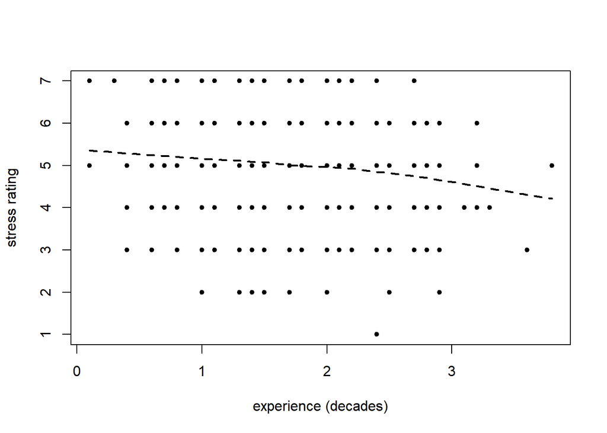

```r
#Scatterplot with LOWESS Line
scatterplot(nurses$stress ~ nurses$exp, ylab='stress rating', xlab='experience (decades)', col='black', boxplot = F, regLine=F, grid=F, smooth=list(smoother=loessLine, var=F, col='black'), pch=20)
```

### Figure 7.2 Scatterplot of relationship between experience and stress for subset of wards

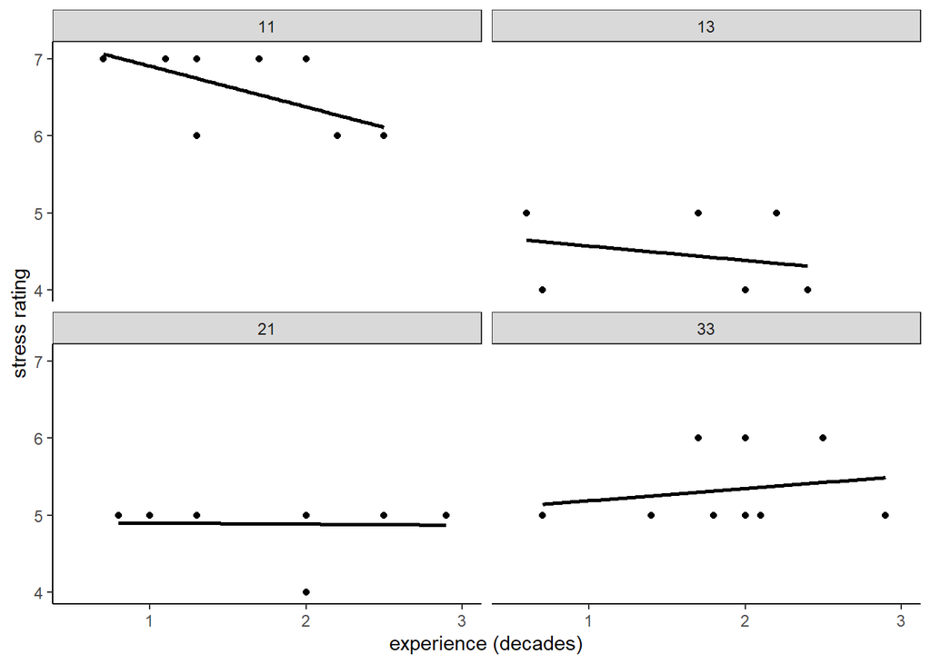

```r
#Create a new dataframe with only a subset of wards
nursesub <- subset(nurses, wardid == 11 | wardid == 13 | wardid == 21 | wardid == 33)

#Scatterplot of stress and experience faceted by ward
ggplot(nursesub, aes(exp, stress))+
  geom_point()+
  xlim(c(0.5,3.0))+
  facet_wrap(~wardid)+
  stat_smooth(method=lm, se=F, color="black")+
  ylab("stress rating")+
  xlab("experience (decades)")+
  theme_bw()+
  theme(panel.border = element_blank(), panel.grid.major =element_blank(),panel.grid.minor = element_blank(), axis.line = element_line(colour = "black"))
```

## **Estimation and Inference for MLM**

### Unconditional Model

A multilevel model can be estimated using the `lmer()` function from the `lme4` package. The syntax of the formula is similar to the `lm()` function, with additional arguments for specifying random effects. In the unconditional model, we have specified `stress` as the outcome, `~ 1` is used to indicate that this model is intercept only (no predictor), and `+(1|wardid)` specifies that we would like the intercept to vary across wards.

```r
mod0 <- lmer(stress ~ 1 + (1|wardid), data=nurses)
summary(mod0)
```

```
Linear mixed model fit by REML. t-tests use Satterthwaite's method [
lmerModLmerTest]
Formula: stress ~ 1 + (1 | wardid)
   Data: nurses

REML criterion at convergence: 1952.4

Scaled residuals:
     Min       1Q   Median       3Q      Max
-2.94699 -0.67691 -0.00005  0.69678  3.12110

Random effects:
 Groups   Name        Variance Std.Dev.
 wardid   (Intercept) 0.6576   0.8109
 Residual             0.3013   0.5489
Number of obs: 1000, groups:  wardid, 100

Fixed effects:
            Estimate Std. Error       df t value Pr(>|t|)
(Intercept)  5.00065    0.08295 99.10147   60.28   <2e-16 ***
---
Signif. codes:  0 '***' 0.001 '**' 0.01 '*' 0.05 '.' 0.1 ' ' 1
```

```r
#Under the random effects output, the standard deviation of the intercepts (i.e., group means) across wards is 0.81.
#The Level 1 residual standard deviation is 0.55, giving the within-ward standard deviation of the stress outcome.
#under the fixed-effect output, the mean intercept (the mean of the group means) is 5.00.
```

### Intraclass correlation

The random-effects variance estimates from the unconditional model can be used to calculate the intraclass correlation for stress. Between-cluster variance is the intercept variance from the unconditional model, and total variance is the sum of the intercept variance and the residual variance.

```r
#Between-cluster variance:
btw <- .6576

#Residual variance:
res <- .3013

#Intraclass correlation:
icc <- btw / (btw+res)
icc
```

```
[1] 0.6857858
```

```r
#The icc matches (with rounding) the ICC(1) estimate provided by the multilevel.descript function:
multilevel.descript(nurses$stress, cluster = nurses$wardid)
```

```
 Multilevel Descriptive Statistics

  Level 1
   No. of cases            1000
   No. of missing values      0

   Variance Within         0.30

  Level 2
   No. of clusters          100
   Average cluster size   10.00
   Min cluster size           9
   Max cluster size          13

   Mean                    5.00
   Variance Between        0.66
   ICC(1)                 0.686
   ICC(2)                 0.956

  Design effect            7.17
  Design effect sqrt       2.68
  Effective sample size  139.43
```

## Conditional Multilevel Models

### Random Intercept Model

Now we add experience as a regressor. Below we use the `Confint()` function (note the upper-case ‘C’) from the `car` package to obtain the Wald-based confidence intervals described in the text. The base `confint` function would construct confidence intervals using the “profile likelihood” approach. In most situations, Wald CIs and profile-likelihood CIs will be extremely close.

```r
#Random intercept model of stress regressed on experience
mod1 <- lmer(stress ~ exp + (1|wardid), data=nurses)
summary(mod1)
```

```
Linear mixed model fit by REML. t-tests use Satterthwaite's method [
lmerModLmerTest]
Formula: stress ~ exp + (1 | wardid)
   Data: nurses

REML criterion at convergence: 1893.5

Scaled residuals:
    Min      1Q  Median      3Q     Max
-2.8446 -0.6774 -0.0076  0.6692  3.1786

Random effects:
 Groups   Name        Variance Std.Dev.
 wardid   (Intercept) 0.6557   0.8098
 Residual             0.2810   0.5301
Number of obs: 1000, groups:  wardid, 100

Fixed effects:
             Estimate Std. Error        df t value Pr(>|t|)
(Intercept)   5.40820    0.09666 181.48908  55.949  < 2e-16 ***
exp          -0.23925    0.02937 908.27129  -8.146 1.23e-15 ***
---
Signif. codes:  0 '***' 0.001 '**' 0.01 '*' 0.05 '.' 0.1 ' ' 1

Correlation of Fixed Effects:
    (Intr)
exp -0.517
```

```r
#Under the random effects output, the standard deviation of the random intercepts is 0.8098.
#This result indicates how much the intercept of the regression of stress on exp varies across wards.

#Under the fixed effects output, the experience slope estimate = -0.239 indicates that stress is expected to be 0.239 lower per decade of nurse experience. But this estimate is a combination of a between-ward effect and a within-ward effect, as explained later in the chapter.
#The intercept fixed-effect estimate = 5.40 is the predicted stress level for a nurse with experience = 0. The intercept standard deviation (0.8098) indicates how much this predicted stress level varies across wards.

Confint(mod1, type="Wald")
```

```
              Estimate      2.5 %     97.5 %
(Intercept)  5.4082036  5.2187467  5.5976604
exp         -0.2392459 -0.2968073 -0.1816845
```

```r
#These confidence intervals pertain to the fixed effects.
```

## Centering Level 1 Regressors

The `center()` function from the `misty` package can be used to easily add centered versions of your variables to your data frame. To create a variable centered within cluster, include the argument `type = "CWC`“, and then specify the cluster/grouping column.

```r
#Creating a variable of nurse experience centered within cluster (i.e., centered around the ward-specific means)
nurses$expCw <- center(nurses$exp, type = "CWC", cluster=nurses$wardid)

#Creating a variable that equals the within-ward means of experience.
#These cluster means will be used as a Level 2 regressor, as explained in the text.
nurses$expMs <- cluster.scores(nurses$exp, cluster = nurses$wardid)
```

### Fitting the model with experience centered within cluster

```r
mod1c <- lmer(stress ~ expCw + (1|wardid), data=nurses)
summary(mod1c)
```

```
Linear mixed model fit by REML. t-tests use Satterthwaite's method [
lmerModLmerTest]
Formula: stress ~ expCw + (1 | wardid)
   Data: nurses

REML criterion at convergence: 1894.1

Scaled residuals:
    Min      1Q  Median      3Q     Max
-2.8418 -0.6784 -0.0050  0.6728  3.1803

Random effects:
 Groups   Name        Variance Std.Dev.
 wardid   (Intercept) 0.6596   0.8122
 Residual             0.2810   0.5301
Number of obs: 1000, groups:  wardid, 100

Fixed effects:
             Estimate Std. Error        df t value Pr(>|t|)
(Intercept)   5.00072    0.08295  99.09464  60.286  < 2e-16 ***
expCw        -0.23884    0.02945 899.09862  -8.111 1.64e-15 ***
---
Signif. codes:  0 '***' 0.001 '**' 0.01 '*' 0.05 '.' 0.1 ' ' 1

Correlation of Fixed Effects:
      (Intr)
expCw 0.000
```

```r
#Under the random effects output, the standard deviation of the random intercepts is 0.8122.
#This result indicates how much the intercept of the regression of stress on exp varies across wards.

#Under the fixed effects output, the experience slope estimate = -0.2388 indicates that stress is expected to be 0.2388 lower per decade of nurse experience. Because experience is now centered within-cluster, this slope estimate is the within-cluster effect (i.e., when comparing two nurses from the same randomly selected ward whose experience differs by 1 decade, the nurse with 1 decade more experience is predicted to have a 0.2388 lower stress level.)
#The intercept fixed-effect estimate = 5.00 is the predicted stress level for a nurse whose experience equals the mean experience in that nurse's ward. The intercept standard deviation (0.8122) indicates how much this predicted stress level varies across wards.

Confint(mod1c, type="Wald")
```

```
              Estimate      2.5 %     97.5 %
(Intercept)  5.0007192  4.8381402  5.1632982
expCw       -0.2388379 -0.2965494 -0.1811265
```

## Random-Slopes Model

### Table 7.4: Random Slopes Model

To add a random slope term, the regressor’s name can be added to the random variable argument. To specify random slopes in addition to random intercepts, you can use `+(x|group)`, which is equivalent to `+(1 + x|group)`. It makes sense to use the within-cluster centered regressor for this model.

```r
#Creating random slopes model for stress regressed on within-ward centered experience:
mod2c <- lmer(stress ~ expCw + (expCw|wardid), data=nurses)
summary(mod2c)
```

```
Linear mixed model fit by REML. t-tests use Satterthwaite's method [
lmerModLmerTest]
Formula: stress ~ expCw + (expCw | wardid)
   Data: nurses

REML criterion at convergence: 1893

Scaled residuals:
    Min      1Q  Median      3Q     Max
-2.8422 -0.6831 -0.0007  0.6735  3.1988

Random effects:
 Groups   Name        Variance Std.Dev. Corr
 wardid   (Intercept) 0.659899 0.81234
          expCw       0.008115 0.09008  0.27
 Residual             0.278138 0.52739
Number of obs: 1000, groups:  wardid, 100

Fixed effects:
            Estimate Std. Error       df t value Pr(>|t|)
(Intercept)  5.00075    0.08295 99.09220  60.286  < 2e-16 ***
expCw       -0.23553    0.03085 81.17273  -7.634  3.9e-11 ***
---
Signif. codes:  0 '***' 0.001 '**' 0.01 '*' 0.05 '.' 0.1 ' ' 1

Correlation of Fixed Effects:
      (Intr)
expCw 0.076
```

```r
#Under the random effects output, the standard deviation of the random intercepts is 0.8122.
#This result indicates how much the intercept of the regression of stress on exp varies across wards.
#The standard deviation of the random slope for the experience effect is 0.09.
#This result indicates how much the slope of the regression of stress on exp varies across wards.
#The correlation between the random intercepts and random slopes is 0.27, indicating a slight tendency for wards with higher intercepts to have higher slopes.

#Under the fixed effects output, the experience slope estimate = -0.2355 is the mean of the ward-specific experience slopes. This fixed slope estimate is the average within-cluster effect of experience (because the radnom slope model allows the within-cluster slope effect to vary across wards).
#The intercept fixed-effect estimate = 5.00 is again the predicted stress level for a nurse whose experience equals the mean experience in that nurse's ward.

#IGNORE the output labeled as "Correlation of Fixed Effects".

Confint(mod2c, type="Wald")
```

```
              Estimate      2.5 %     97.5 %
(Intercept)  5.0007457  4.8381660  5.1633254
expCw       -0.2355279 -0.2960005 -0.1750552
```

### Table 7.5: Random Intercept Model with Level 2 regressor

```r
mod3 <- lmer(stress ~ intervention + (1|wardid), data=nurses)
summary(mod3)
```

```
Linear mixed model fit by REML. t-tests use Satterthwaite's method [
lmerModLmerTest]
Formula: stress ~ intervention + (1 | wardid)
   Data: nurses

REML criterion at convergence: 1934.5

Scaled residuals:
     Min       1Q   Median       3Q      Max
-2.98755 -0.67691 -0.02863  0.69295  3.09196

Random effects:
 Groups   Name        Variance Std.Dev.
 wardid   (Intercept) 0.5378   0.7333
 Residual             0.3013   0.5489
Number of obs: 1000, groups:  wardid, 100

Fixed effects:
             Estimate Std. Error      df t value Pr(>|t|)
(Intercept)    5.3523     0.1066 97.9504  50.194  < 2e-16 ***
intervention  -0.7034     0.1508 97.8768  -4.665 9.78e-06 ***
---
Signif. codes:  0 '***' 0.001 '**' 0.01 '*' 0.05 '.' 0.1 ' ' 1

Correlation of Fixed Effects:
            (Intr)
interventin -0.707
```

```r
#Under the fixed effects output, the intervention slope estimate indicates that the predicted mean stress level in wards receiving the intervention is 0.7034 lower than the predicted mean stress level in control-group wards.
#The fixed intercept estimate = 5.3523 is the predicted mean stress level in control group wards.

#Under the random effects output, the intercept standard deviation indicates how much the mean stress level varies across wards after accounting for the intervention effect.

Confint(mod3)
```

```
               Estimate      2.5 %     97.5 %
(Intercept)   5.3522641  5.1432704  5.5612579
intervention -0.7033715 -0.9988781 -0.4078648
```

### Table 7.6: Random Slope Model with Level 1 and Level 2 Variable

```r
#both level 1 and level 2
mod4 <- lmer(stress ~ intervention + expCw + (expCw|wardid), data=nurses)
summary(mod4)
```

```
Linear mixed model fit by REML. t-tests use Satterthwaite's method [
lmerModLmerTest]
Formula: stress ~ intervention + expCw + (expCw | wardid)
   Data: nurses

REML criterion at convergence: 1874.9

Scaled residuals:
    Min      1Q  Median      3Q     Max
-2.8488 -0.6713 -0.0103  0.6859  3.1692

Random effects:
 Groups   Name        Variance Std.Dev. Corr
 wardid   (Intercept) 0.540109 0.73492
          expCw       0.007725 0.08789  0.33
 Residual             0.278308 0.52755
Number of obs: 1000, groups:  wardid, 100

Fixed effects:
             Estimate Std. Error       df t value Pr(>|t|)
(Intercept)   5.35309    0.10641 98.36319  50.306  < 2e-16 ***
intervention -0.70481    0.15015 97.89394  -4.694 8.72e-06 ***
expCw        -0.23640    0.03078 80.83104  -7.679 3.24e-11 ***
---
Signif. codes:  0 '***' 0.001 '**' 0.01 '*' 0.05 '.' 0.1 ' ' 1

Correlation of Fixed Effects:
            (Intr) intrvn
interventin -0.706
expCw        0.058  0.009
```

```r
Confint(mod4, type="Wald")
```

```
               Estimate      2.5 %     97.5 %
(Intercept)   5.3530861  5.1445249  5.5616473
intervention -0.7048117 -0.9991021 -0.4105213
expCw        -0.2364030 -0.2967403 -0.1760658
```

### Model with Cross-Level Interaction

To specify a cross-level interaction, identical to specifying interactions in multiple regression models, the `*` symbol is used.

```r
#cross-level interaction
mod5 <- lmer(stress ~ intervention + expCw + (intervention*expCw) + (expCw|wardid), data=nurses)
summary(mod5)
```

```
Linear mixed model fit by REML. t-tests use Satterthwaite's method [
lmerModLmerTest]
Formula: stress ~ intervention + expCw + (intervention * expCw) + (expCw |
    wardid)
   Data: nurses

REML criterion at convergence: 1878.6

Scaled residuals:
    Min      1Q  Median      3Q     Max
-2.8492 -0.6731 -0.0088  0.6862  3.1680

Random effects:
 Groups   Name        Variance Std.Dev. Corr
 wardid   (Intercept) 0.540155 0.73495
          expCw       0.008645 0.09298  0.31
 Residual             0.278322 0.52756
Number of obs: 1000, groups:  wardid, 100

Fixed effects:
                    Estimate Std. Error        df t value Pr(>|t|)
(Intercept)         5.352295   0.106634 97.954164  50.193  < 2e-16 ***
intervention       -0.703229   0.150778 97.886283  -4.664 9.83e-06 ***
expCw              -0.240100   0.046176 98.382915  -5.200 1.09e-06 ***
intervention:expCw  0.006995   0.062233 83.018569   0.112    0.911
---
Signif. codes:  0 '***' 0.001 '**' 0.01 '*' 0.05 '.' 0.1 ' ' 1

Correlation of Fixed Effects:
            (Intr) intrvn expCw
interventin -0.707
expCw        0.087 -0.062
intrvntn:xC -0.065  0.091 -0.742
```

### Table 7.7: Disentangling within and between effects

```r
#within- and between-ward effects of experience
mod6 <- lmer(stress ~ expCw + expMs + (expCw|wardid), data=nurses)
summary(mod6)
```

```
Linear mixed model fit by REML. t-tests use Satterthwaite's method [
lmerModLmerTest]
Formula: stress ~ expCw + expMs + (expCw | wardid)
   Data: nurses

REML criterion at convergence: 1892.5

Scaled residuals:
    Min      1Q  Median      3Q     Max
-2.8457 -0.6760 -0.0046  0.6744  3.1959

Random effects:
 Groups   Name        Variance Std.Dev. Corr
 wardid   (Intercept) 0.662680 0.81405
          expCw       0.008199 0.09055  0.24
 Residual             0.278114 0.52737
Number of obs: 1000, groups:  wardid, 100

Fixed effects:
            Estimate Std. Error       df t value Pr(>|t|)
(Intercept)  5.47912    0.70107 98.21271   7.815 6.20e-12 ***
expCw       -0.23579    0.03087 81.22773  -7.638 3.82e-11 ***
expMs       -0.28086    0.40871 98.18147  -0.687    0.494
---
Signif. codes:  0 '***' 0.001 '**' 0.01 '*' 0.05 '.' 0.1 ' ' 1

Correlation of Fixed Effects:
      (Intr) expCw
expCw  0.005
expMs -0.993  0.004
```

```r
Confint(mod6)
```

```
              Estimate      2.5 %     97.5 %
(Intercept)  5.4791195  4.1050508  6.8531883
expCw       -0.2357857 -0.2962931 -0.1752784
expMs       -0.2808625 -1.0819186  0.5201937
```

### R<sup>2</sup> Measures

R<sup>2</sup> values can be obtained for multilevel models by using the `multilevel.r2` function from the `misty` package.

```r
multilevel.r2(mod4)
```

```
 R-Squared Measures for Multilevel and Linear Mixed Effects Models

  Integrative Framework of R-Squared Measures (Rights and Sterba, 2019)

   Total R2
       f1    f2     f     v     m    fv   fvm
    0.019 0.129 0.148 0.003 0.561 0.150 0.711

   Within-Cluster R2
       f1     v   f1v
    0.061 0.008 0.069

   Between-Cluster R2
       f2     m
    0.187 0.813
```

```r
#Under the Total R^2 output, the value for "f1" indicates that the Level 1 regressors (only experience in this model) explain 2% of the total variance of stress across all nurses and wards. The value for "f2" = .13 is the proportion of total variance explained by the fixed effects of the Level 2 regressors (intervention in this model). With this model, the ward-level intervention regressor explains 13% of the total stress variance.
#Finally, the value under "f" is the total variance explained by the fixed effects of both level 1 and Level 2 regressors. Here, 0.148 of total stress experience is explained by the combination of nurse experience and the intervention variables.
```

### Formal Model Comparisons

A likelihood ratio test (LRT) can be used to compare the fit of nested models. In the example below, we compare the random intercepts model of nurse stress regressed on experience (with nurses clustered within wards, intercepts allowed to vary across wards) and the random slopes model of nurse stress regressed on experience (with nurses clustered within wards, intercepts and slopes allowed to vary across wards).

```r
#comparing model simple model to model with an additional parameter (random slope term)
anova(mod1c, mod2c)
```

|  | npar | AIC | BIC | logLik | -2*log(L) | Chisq | Df | Pr(>Chisq) |
| --- | --- | --- | --- | --- | --- | --- | --- | --- |
| mod1c | 4 | 1893.713 | 1913.344 | -942.8565 | 1885.713 | NA | NA | NA |
| mod2c | 6 | 1896.745 | 1926.191 | -942.3724 | 1884.745 | 0.9681341 | 2 | 0.6162719 |

Note: When using the `anova()` function, the models are refit using full maximum likelihood estimation. The models we estimated using the `lmer()` function were estimated using restricted maximum likelihood. Consequently, the AIC and BIC values presented in the `anova()` output will slightly differ from the values yielded from passing our models through other AIC or BIC functions (e.g., `AIC()` and `BIC()`).

### Figure 7.6: Residuals vs. Fitted Value Plot

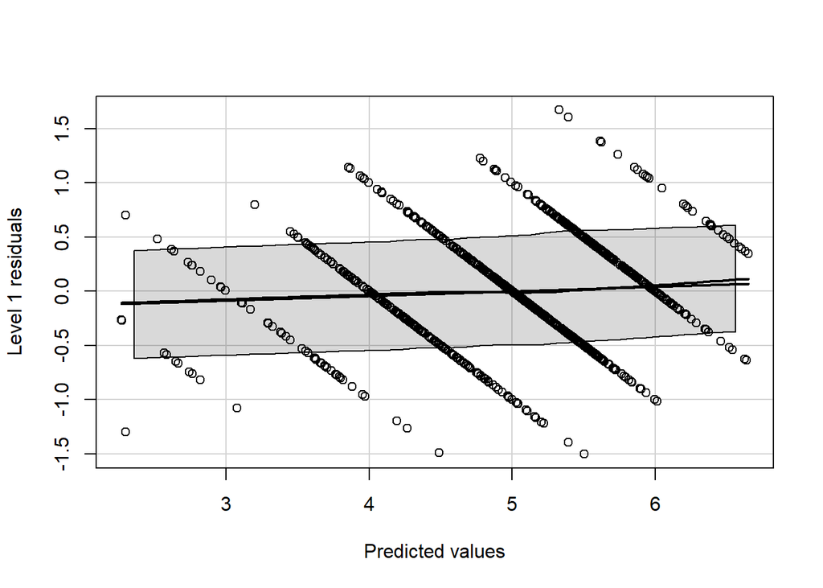

```r
#Residuals vs fitted value plot
scatterplot(resid(mod4) ~ fitted(mod4), boxplots="", smooth=list(smoother=loessLine, lty.smooth=1), col="black", xlab="Predicted values",
            ylab="Level 1 residuals")
```

### Figure 7.7: QQ-Plot of Level 1 Residuals

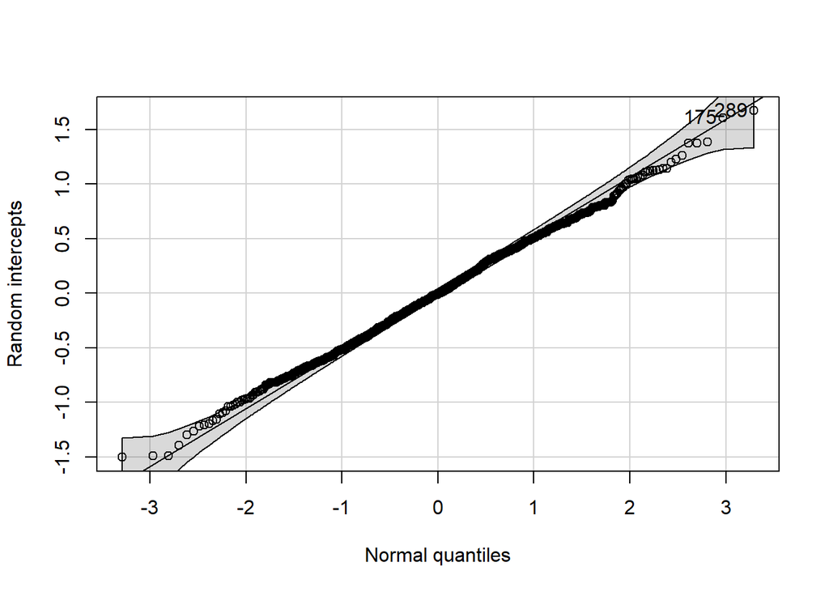

```
[1] 289 175
```

```r
qqPlot(resid(mod4), ylab = "Random intercepts", xlab = "Normal quantiles", col.lines = "black", lwd=1)
```

### Figure 7.8: QQ-Plot of Random Effects

The `ranef()` function can be used to extract the random intercept and slope estimates of each cluster.

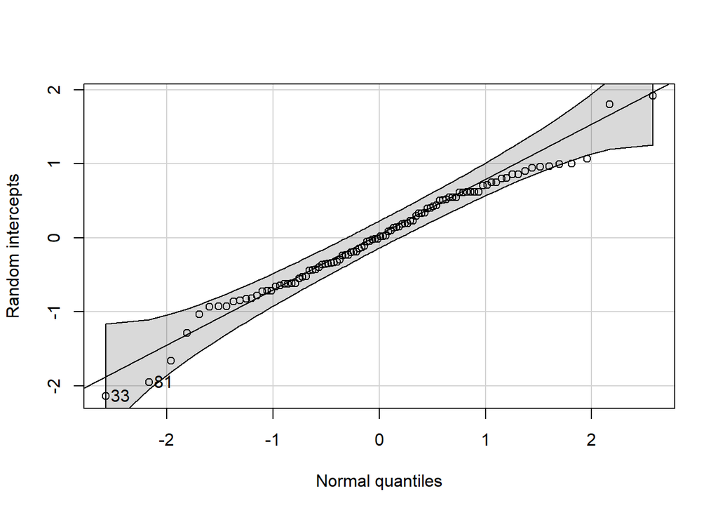

```
[1] 33 81
```

```r
ranefs <- as.data.frame(ranef(mod4))

#the first 100 random effects are the intercept estimates for the 100 hospital wards (clusters)
intcpts <- ranefs[1:100,]
qqPlot(intcpts$condval, ylab = "Random intercepts", xlab = "Normal quantiles", col.lines = "black", lwd=1)
```

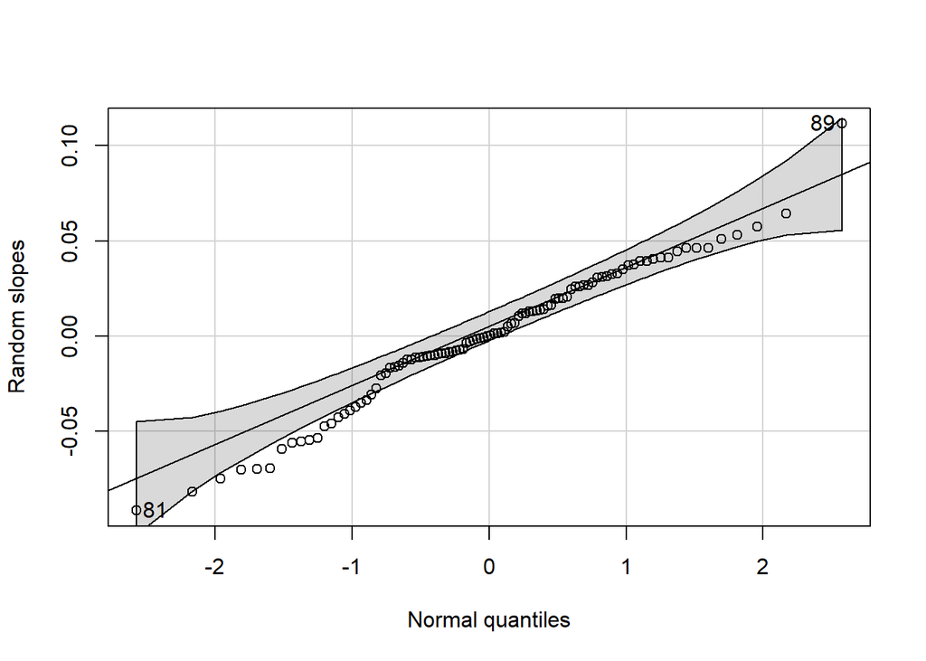

```
[1] 89 81
```

```r
#the next 100 random effects are the slope estimates for the 100 hospital wards (clusters)
slopes <- ranefs[101:200,]
qqPlot(slopes$condval, ylab = "Random slopes", xlab = "Normal quantiles", col.lines = "black", lwd=1)
```

## Three-level models

The models presented in this section are described in the online Supplementary Text for Chapter 7.

### Three-level intercept-only model

The intercept-only model (i.e., unconditional model) for nurses nested within wards, and wards nested within hospitals, can be estimated as follows:

```r
uncond3l <- lmer(stress ~ 1 + (1|hospital/wardid), data=nurses)

#alternative way to specify the same model:
#uncond3l <- lmer(stress ~ 1 + (1|wardid) + (1|hospital), data=nurses)

summary(uncond3l)
```

```
Linear mixed model fit by REML. t-tests use Satterthwaite's method [
lmerModLmerTest]
Formula: stress ~ 1 + (1 | hospital/wardid)
   Data: nurses

REML criterion at convergence: 1945

Scaled residuals:
     Min       1Q   Median       3Q      Max
-2.97604 -0.65739  0.01792  0.67398  3.11229

Random effects:
 Groups          Name        Variance Std.Dev.
 wardid:hospital (Intercept) 0.4888   0.6992
 hospital        (Intercept) 0.1743   0.4175
 Residual                    0.3013   0.5489
Number of obs: 1000, groups:  wardid:hospital, 100; hospital, 25

Fixed effects:
            Estimate Std. Error      df t value Pr(>|t|)
(Intercept)   5.0010     0.1103 24.0040   45.34   <2e-16 ***
---
Signif. codes:  0 '***' 0.001 '**' 0.01 '*' 0.05 '.' 0.1 ' ' 1
```

```r
#Random effects:
#The variance of the hospital-specific means is 0.17 (corresponding to SD = 0.42).
#The variance of the ward-specific means within a given hospital is 0.49 (SD = 0.70).

#Fixed effect:
#The grand mean level of stress is  = 5.00
```

The variance estimates from the intercept-only model could be used to calculate the intraclass correlations described in the online supplement. Alternatively, these ICCs can be calculated using the `icc()` function from the `performance` package and the `iccMixed()` function from the `multilevelTools` package:

```r
#install packages if you don't have them already:
#install.packages("performance")
#install.packages("multilevelTools")

library(performance)
#the argument for the icc() function is the name of the intercept-only model we just estimated:
icc(uncond3l)
```

| ICC_adjusted | ICC_unadjusted | optional |
| --- | --- | --- |
| 0.6876163 | 0.6876163 | FALSE |

```r
#69% of total variance is due to the sum of between-ward (level 2) and between-hospital (level 3) variance.

library(multilevelTools)
#Instead of referring to the estimated model, the arguments for the iccMixed() function are the name of the outcome variable, the names of the id variables for the two- and three-level units, and the data frame:
iccMixed("stress", c("wardid", "hospital"), nurses)
```

| Var | Sigma | ICC |
| --- | --- | --- |
| wardid | 0.4888231 | 0.5068777 |
| hospital | 0.1743008 | 0.1807386 |
| Residual | 0.3012569 | 0.3123837 |

```r
#ICCL2 = 0.51 is the proportion of variance due to nesting of nurses within wards
#ICCL3 = 0.18 is the proportion of variance due to nesting of wards within hospitals.
```

### Conditional three-level models

We can estimate a three-level, random slopes model of stress regressed on within-ward centered experience as follows:

```r
ranslope3l <- lmer(stress ~ expCw + (expCw|hospital/wardid), data=nurses)
# Or:
#mod.rs <- lmer(stress ~ expCw + (expCw|wardid) + (expCw|hospital), data=nurses)

#A boundary warning results!

summary(ranslope3l)
```

```
Linear mixed model fit by REML. t-tests use Satterthwaite's method [
lmerModLmerTest]
Formula: stress ~ expCw + (expCw | hospital/wardid)
   Data: nurses

REML criterion at convergence: 1884.8

Scaled residuals:
    Min      1Q  Median      3Q     Max
-2.8864 -0.6735  0.0102  0.6720  3.1960

Random effects:
 Groups          Name        Variance Std.Dev. Corr
 wardid:hospital (Intercept) 0.490436 0.70031
                 expCw       0.006213 0.07882  0.03
 hospital        (Intercept) 0.174960 0.41828
                 expCw       0.002193 0.04683  1.00
 Residual                    0.278090 0.52734
Number of obs: 1000, groups:  wardid:hospital, 100; hospital, 25

Fixed effects:
            Estimate Std. Error       df t value Pr(>|t|)
(Intercept)  5.00107    0.11038 24.06326  45.306  < 2e-16 ***
expCw       -0.23681    0.03194 48.21718  -7.415 1.66e-09 ***
---
Signif. codes:  0 '***' 0.001 '**' 0.01 '*' 0.05 '.' 0.1 ' ' 1

Correlation of Fixed Effects:
      (Intr)
expCw 0.227
optimizer (nloptwrap) convergence code: 0 (OK)
boundary (singular) fit: see help('isSingular')
```

```r
#The perfect correlation between hospital-level intercepts and slopes can be considered an improper estimate.
```

Revised model with random intercepts and slopes at Level 2 (ward level), but only random intercepts at Level 3 (hospital level):

```r
ranslope3l.b <- lmer(stress ~ expCw + (expCw|wardid) + (1|hospital), data=nurses)
summary(ranslope3l.b)
```

```
Linear mixed model fit by REML. t-tests use Satterthwaite's method [
lmerModLmerTest]
Formula: stress ~ expCw + (expCw | wardid) + (1 | hospital)
   Data: nurses

REML criterion at convergence: 1885.9

Scaled residuals:
    Min      1Q  Median      3Q     Max
-2.8697 -0.6677  0.0000  0.6701  3.1864

Random effects:
 Groups   Name        Variance Std.Dev. Corr
 wardid   (Intercept) 0.493142 0.70224
          expCw       0.008221 0.09067  0.17
 hospital (Intercept) 0.170099 0.41243
 Residual             0.278096 0.52735
Number of obs: 1000, groups:  wardid, 100; hospital, 25

Fixed effects:
            Estimate Std. Error       df t value Pr(>|t|)
(Intercept)  5.00104    0.10962 23.90541  45.620  < 2e-16 ***
expCw       -0.23613    0.03088 81.12677  -7.646 3.69e-11 ***
---
Signif. codes:  0 '***' 0.001 '**' 0.01 '*' 0.05 '.' 0.1 ' ' 1

Correlation of Fixed Effects:
      (Intr)
expCw 0.032
```

##Higher-level random slope

We can estimate a three-level model in which the slope of a Level 2 regressor (intervention) varies across Level 3 units (hospitals), while holding a Level 1 regressor (experience) constant:

```r
ranslope23 <- lmer(stress ~ expCw + intervention + (expCw|wardid) + (intervention|hospital), data=nurses)
summary(ranslope23)
```

```
Linear mixed model fit by REML. t-tests use Satterthwaite's method [
lmerModLmerTest]
Formula: stress ~ expCw + intervention + (expCw | wardid) + (intervention |
    hospital)
   Data: nurses

REML criterion at convergence: 1822.8

Scaled residuals:
    Min      1Q  Median      3Q     Max
-2.9283 -0.6625 -0.0023  0.6699  3.1713

Random effects:
 Groups   Name         Variance Std.Dev. Corr
 wardid   (Intercept)  0.112632 0.33561
          expCw        0.008555 0.09249  0.33
 hospital (Intercept)  0.154896 0.39357
          intervention 0.677866 0.82333  -0.18
 Residual              0.277949 0.52721
Number of obs: 1000, groups:  wardid, 100; hospital, 25

Fixed effects:
             Estimate Std. Error       df t value Pr(>|t|)
(Intercept)   5.35304    0.09489 24.00365  56.411  < 2e-16 ***
expCw        -0.23721    0.03093 81.58647  -7.669 3.24e-11 ***
intervention -0.70337    0.18084 23.91291  -3.889    7e-04 ***
---
Signif. codes:  0 '***' 0.001 '**' 0.01 '*' 0.05 '.' 0.1 ' ' 1

Correlation of Fixed Effects:
            (Intr) expCw
expCw        0.031
interventin -0.301  0.004
```

```r
#See the online supplement for interpretations of the estimates.
```